# CCLE expression analysis related to spliceosomal mutations

Leticia Castillon

23-11-2020

source R profile. Memory was set to 500000.

```r
Sys.setenv("R_ENVIRON_USER"='/Users/castilln/.Renviron')
Sys.getenv("R_ENVIRON_USER")
```

```
## [1] "/Users/castilln/.Renviron"
```

# Load expression data & spliceosome data

```r
CCLE_expression <- fread("/Users/castilln/Desktop/thesis/localdata/depmap/CCLE_expression.csv", header = TRUE)
#rows: tumor sample barcode
#column: genes
#values: expression (TPM) already log2 transformed

sample_info <- read_csv("/Users/castilln/Desktop/thesis/localdata/depmap/sample_info.csv") #metadata
CCLE_mutations <- fread("/Users/castilln/Desktop/thesis/localdata/depmap/CCLE_info", header = TRUE) #mutations and sample info

mutations_spliceosome = fread("/Users/castilln/Desktop/thesis/localdata/depmap/mutations_spliceosome.csv")
```

Contingency table - Annotation of cell lines with spliceosome mutations

```r
cell_lines_list =
  CCLE_mutations %>%
  select(stripped_cell_line_name, primary_disease, DepMap_ID)

cell_lines_list_mutated =
 cell_lines_list %>%
   mutate(spliceosome_mutated =
           case_when(
            cell_lines_list$stripped_cell_line_name %in% mutations_spliceosome$stripped_cell_line_name ~ "YES", #if the mutation is in a gene from the spliceosome: 1
            !cell_lines_list$stripped_cell_line_name %in% mutations_spliceosome$stripped_cell_line_name ~ "NO")) %>%
  distinct()

cell_lines_list_mutated %>%
  distinct() %>%
  group_by(primary_disease,spliceosome_mutated) %>%
  tally()
```

| primary_disease | spliceosome_mutated | n |
| --- | --- | --- |
| Adrenal Cancer | YES | 1 |
| Bile Duct Cancer | NO | 3 |
| Bile Duct Cancer | YES | 33 |
| Bladder Cancer | YES | 39 |
| Bone Cancer | NO | 10 |
| Bone Cancer | YES | 65 |
| Brain Cancer | NO | 8 |
| Brain Cancer | YES | 99 |
| Breast Cancer | NO | 16 |
| Breast Cancer | YES | 66 |

[output cut: 48 more lines]

```r
table(distinct(cell_lines_list_mutated)$primary_disease,distinct(cell_lines_list_mutated)$spliceosome_mutated)
```

```
##
##                               NO YES
##   Adrenal Cancer               0   1
##   Bile Duct Cancer             3  33
##   Bladder Cancer               0  39
##   Bone Cancer                 10  65
##   Brain Cancer                 8  99
##   Breast Cancer               16  66
##   Cervical Cancer              0  22
##   Colon/Colorectal Cancer      4  79
##   Embryonal Cancer             0   3
##   Endometrial/Uterine Cancer   1  38
##   Engineered                   9   5
##   Esophageal Cancer            0  38
##   Eye Cancer                   0   9
##   Fibroblast                   5  38
##   Gallbladder Cancer           0   7
##   Gastric Cancer               2  47
##   Head and Neck Cancer         4  72
##   Kidney Cancer                6  50
##   Leukemia                     9 123
##   Liposarcoma                  0  11
##   Liver Cancer                 0  27
##   Lung Cancer                 12 261
##   Lymphoma                     4 105
##   Myeloma                      1  33
##   Neuroblastoma                1  45
##   Non-Cancerous                2   3
##   Ovarian Cancer               5  69
##   Pancreatic Cancer            8  51
##   Prostate Cancer              0  13
##   Rhabdoid                     1  19
##   Sarcoma                      7  35
##   Skin Cancer                  7 106
##   Teratoma                     0   1
##   Thyroid Cancer               0  21
##   Unknown                      9  36
```

```r
spliceosome_mutated_ID =
  cell_lines_list_mutated %>%
  select(DepMap_ID, spliceosome_mutated) %>%
  distinct()
```

### Differential Expression Analysis

```r
#make sure expression data is normally distributed
#central limit theorem: sample size large enough to assume normal distribution
CCLE_expression =
  CCLE_expression %>%
  rename("DepMap_ID" = "V1")

#join expression data with metadata
long_CCLE_expression =
  CCLE_expression %>%
  pivot_longer(cols=-DepMap_ID, names_to = "Gene", values_to = "TPM") %>%
  left_join(cell_lines_list_mutated, by = "DepMap_ID")
```

#Lets see the distribution of the expression data

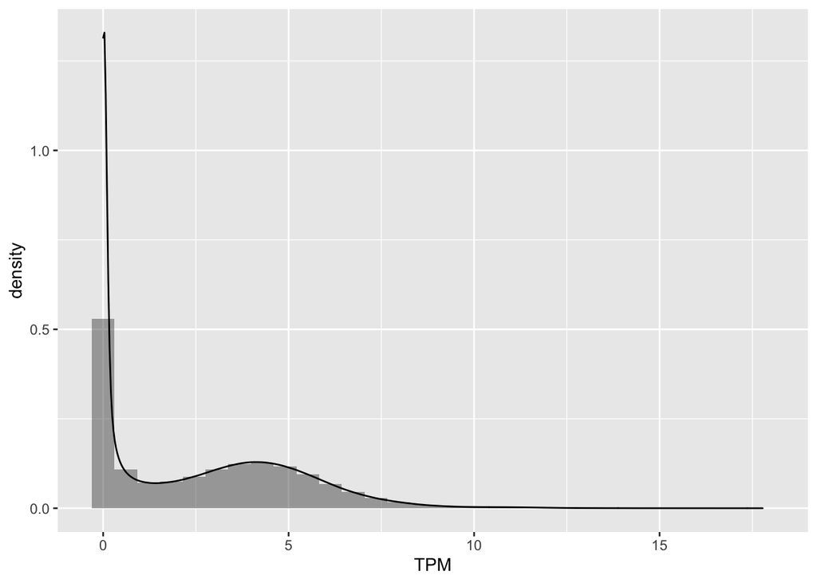

```r
library(ggdist)
ggplot(long_CCLE_expression, aes(x=TPM)) +
  geom_histogram(aes(y=..density..), position="identity", alpha=0.5) +
  geom_density(alpha=0.6)
```

Filter out those genes whose median for expression is lower than 1 across all samples

```r
median_CCLE_expression =
  long_CCLE_expression %>%
  group_by(Gene) %>%
  dplyr::mutate(median = median(TPM, na.rm=TRUE)) %>%
  filter(median >= 1)
```

Plot again

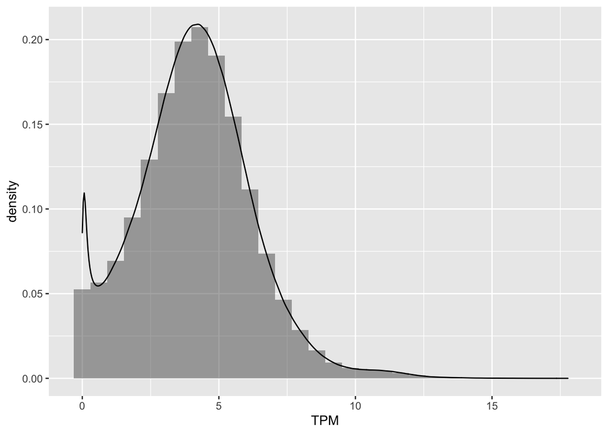

```r
ggplot(median_CCLE_expression, aes(x=TPM)) +
  geom_histogram(aes(y=..density..), position="identity", alpha=0.5) +
  geom_density(alpha=0.6)
```

After joinin with the expression data, let’s see how many cell lines we have mutated or not mutated

```r
median_CCLE_expression =
  median_CCLE_expression %>%
  rename("cell_line" = "stripped_cell_line_name")

median_CCLE_expression %>%
  ungroup() %>%
  select(primary_disease, cell_line, spliceosome_mutated) %>%
  distinct() %>%
  group_by(primary_disease, spliceosome_mutated) %>%
  tally()
```

| primary_disease | spliceosome_mutated | n |
| --- | --- | --- |
| Adrenal Cancer | YES | 1 |
| Bile Duct Cancer | NO | 3 |
| Bile Duct Cancer | YES | 32 |
| Bladder Cancer | YES | 36 |
| Bone Cancer | NO | 5 |
| Bone Cancer | YES | 34 |
| Brain Cancer | NO | 2 |
| Brain Cancer | YES | 82 |
| Breast Cancer | YES | 61 |
| Cervical Cancer | YES | 18 |

[output cut: 39 more lines]

```r
median_CCLE_expression %>%
  ungroup %>%
  select(cell_line) %>%
  distinct() %>% dim()
```

```
## [1] 1369    1
```

Let’s keep only those cancers with a relatively significant number of cell lines w/o mutations in the spliceosome:

```r
keep <- c("Bone Cancer", "Pancreatic Cancer", "Leukemia")

df_deseq =
median_CCLE_expression %>%
  filter(primary_disease %in% keep)
```

# t-test

```r
#filt_CCLE_expression %>%
  df_deseq %>%
  select(DepMap_ID, Gene, TPM, spliceosome_mutated) %>%
  filter(spliceosome_mutated == "NO") %>%
  select(c(Gene, TPM))-> no_t_expression

#head(no_t_expression)

#filt_CCLE_expression %>%
df_deseq %>%
  select(DepMap_ID, Gene, TPM, spliceosome_mutated) %>%
  filter(spliceosome_mutated == "YES") %>%
  select(c(Gene, TPM)) -> yes_t_expression

#head(yes_t_expression)

t.test(no_t_expression$TPM, yes_t_expression$TPM, alternative = "two.sided", var.equal = FALSE)
```

```
##
##  Welch Two Sample t-test
##
## data:  no_t_expression$TPM and yes_t_expression$TPM
## t = 7.0946, df = 250114, p-value = 1.3e-12
## alternative hypothesis: true difference in means is not equal to 0
## 95 percent confidence interval:
##  0.02553765 0.04503382
## sample estimates:
## mean of x mean of y
##  4.100692  4.065406
```

# Create DGElist

A DGElist object conveniently stores count matrix, sample metadata and gene annotation as one object for easy manipulation.

## Count matrix

```r
df_counts = df_deseq %>%
  select(cell_line, Gene, TPM) %>%
  pivot_wider(names_from = cell_line, values_from = TPM) %>%
  as.data.frame()

#STORE FIRST COLUMN AS ROWNAMES
rownames(df_counts) = df_counts[,1]

rownames(df_counts) <- gsub("\\s*\\([^\\)]+\\)","",as.character(rownames(df_counts)))

#REMOVE FIRST COLUMN
df_counts = df_counts[,-1]

##THERE ARE NA VALUES IN DF_COUNTS. SUBSTITUTE NA VALUES BY THE MEAN EXPRESSION FOR THAT CELL LINE
for(i in 1:ncol(df_counts)){
  df_counts[is.na(df_counts[,i]), i] <- mean(df_counts[,i], na.rm = TRUE)
}
```

```r
meta =
  df_deseq %>%
  ungroup() %>%
  select(-c("TPM", "median", "Gene")) %>%
  distinct()
```

Reorder count columns by meta ID

```r
##REORDER COLUMNS BY SAMPLE INFO
df_counts = df_counts[meta$cell_line]

head(df_counts)
```

|  | KCIMOH1 | PACADD119 | OS252 | KASUMI2 | MONOMAC6 | PACADD137 | CFPAC1 | MHHCALL2 | L33 | CHLA9 | TC106 | ASPC1 | PANC0213 | PLB985 | YAPC | U937 | REH | MUTZ8 | PACADD188 | HG3 | HUPT4 | SIGM5 | HSB2 | HL60 | CAPAN1 | PACADD159 | CHLA10 | OCIM1 | PANC1 | … |
| --- | --- | --- | --- | --- | --- | --- | --- | --- | --- | --- | --- | --- | --- | --- | --- | --- | --- | --- | --- | --- | --- | --- | --- | --- | --- | --- | --- | --- | --- | --- |
| TSPAN6 | 6.706807 | 4.584361 | 5.216067 | 0.12432814 | 0.1634987 | 5.41142625 | 5.225738 | 0.0976108 | 5.064366 | 5.05093697 | 5.807613 | 5.92955432 | 4.714795 | 0.08406426 | 5.649328 | 0.04264434 | 0.11103131 | 0.5753123 | 4.615887 | 0.000000 | 5.239169 | 0.0976108 | 3.5704629 | 0.1890338 | 4.513491 | 4.223423 | 6.5917093 | 1.195348 | 2.4302853 | … |
| DPM1 | 6.726559 | 7.174127 | 7.557655 | 5.63546420 | 6.1151997 | 7.31152128 | 6.304511 | 5.5270078 | 6.302136 | 6.18090371 | 6.368419 | 6.34589309 | 6.745910 | 5.48703608 | 6.674828 | 6.20652602 | 6.22997239 | 4.8459918 | 6.894575 | 4.437627 | 6.868884 | 6.4865535 | 5.9469647 | 5.6334312 | 6.399000 | 4.083213 | 5.4422800 | 6.482042 | 6.1519806 | … |
| SCYL3 | 3.258519 | 2.238787 | 1.545968 | 3.20789285 | 2.7697717 | 3.28540222 | 2.853996 | 2.5825560 | 2.414136 | 2.84398384 | 1.956057 | 2.61117238 | 2.776104 | 1.61353165 | 3.085765 | 2.34198575 | 2.39506280 | 1.8718436 | 2.220330 | 2.014355 | 1.941106 | 2.6507646 | 2.5993178 | 1.2630344 | 2.684819 | 1.090853 | 2.8953026 | 2.432959 | 2.3391374 | … |
| C1orf112 | 3.127633 | 4.860466 | 3.012569 | 4.74308406 | 4.2055489 | 4.69376571 | 3.514753 | 3.9671686 | 3.887525 | 5.42425029 | 3.633431 | 2.27500705 | 3.621759 | 3.10097765 | 3.790772 | 4.31759350 | 4.39163026 | 2.6848187 | 3.488001 | 2.066950 | 2.883621 | 4.0565835 | 4.3582556 | 3.1521834 | 3.414136 | 2.629939 | 4.9159989 | 3.267536 | 3.5594918 | … |
| CFH | 4.949068 | 1.929791 | 4.920293 | 0.08406426 | 3.9420453 | 0.07038933 | 3.740928 | 0.1110313 | 6.584512 | 0.00000000 | 2.053111 | 0.05658353 | 3.095924 | 0.13750352 | 3.878725 | 0.07038933 | 0.02856915 | 2.3757345 | 5.386811 | 0.000000 | 3.612352 | 0.2016339 | 0.1375035 | 0.1634987 | 1.875780 | 2.073820 | 0.4646683 | 6.048977 | 0.0976108 | … |
| FUCA2 | 5.802710 | 6.222070 | 6.747790 | 2.53106949 | 5.2679103 | 5.32264926 | 5.451541 | 0.6780719 | 5.111031 | 0.02856915 | 0.000000 | 5.47994190 | 6.936049 | 0.33342373 | 6.167519 | 5.69348696 | 0.31034012 | 5.0755326 | 5.010780 | 3.534809 | 6.034084 | 3.1618877 | 0.3448285 | 4.1618877 | 5.243364 | 4.164304 | 0.4646683 | 5.978882 | 5.9429836 | … |

Create grouping factor

```r
meta =
  meta %>%
  mutate(group = as.factor(spliceosome_mutated)) %>%
  select(-spliceosome_mutated) %>%
  mutate(primary_disease = as.factor(primary_disease))
```

Create gene annotation

```r
#SOMETIMES PROBLEMS TO LOAD THIS LIBRARIES BECAUSE INCOMPATIBILITIES W/ COMPLEX HEATMAP: START NEW R SESSION
library("AnnotationDbi")
library("org.Hs.eg.db")
gene_annot = AnnotationDbi::mapIds(org.Hs.eg.db, keys = rownames(df_counts),
                                  column = c("GENENAME"), keytype = ("SYMBOL")) %>%
  as.data.frame()
colnames(gene_annot) = c("DESCRIPTION")
```

## Make grouping factor in DGEList

Change primary_disease names to something understandable for R as names

```r
meta$primary_disease = gsub(" ", "_", meta$primary_disease)
meta$primary_disease = gsub("/", "_", meta$primary_disease)
```

```r
dge = DGEList(counts = df_counts,
              samples = meta,
              genes = gene_annot)

summary(dge)
```

```
##         Length  Class      Mode
## counts  2165430 -none-     numeric
## samples       6 data.frame list
## genes         1 data.frame list
```

# Filtering and pre-process

Filter low expressed genes

```r
#keep  = filterByExpr(dge, group = group)
#dge = dge[keep, , keep.lib.sizes = FALSE]
```

Calculate library normalization factors

```r
dge <- calcNormFactors(dge)
dge$samples
```

|  | group | lib.size | norm.factors | DepMap_ID | cell_line | primary_disease |
| --- | --- | --- | --- | --- | --- | --- |
| KCIMOH1 | YES | 46291.24 | 0.9790080 | ACH-001098 | KCIMOH1 | Pancreatic_Cancer |
| PACADD119 | NO | 48564.90 | 0.9839556 | ACH-001375 | PACADD119 | Pancreatic_Cancer |
| OS252 | YES | 48108.76 | 0.9809691 | ACH-001814 | OS252 | Bone_Cancer |
| KASUMI2 | YES | 47481.98 | 1.0155307 | ACH-000728 | KASUMI2 | Leukemia |
| MONOMAC6 | YES | 48806.74 | 1.0134564 | ACH-000006 | MONOMAC6 | Leukemia |
| PACADD137 | YES | 46979.65 | 0.9876345 | ACH-001377 | PACADD137 | Pancreatic_Cancer |
| CFPAC1 | YES | 47623.93 | 0.9559829 | ACH-000138 | CFPAC1 | Pancreatic_Cancer |
| MHHCALL2 | YES | 48381.25 | 1.0166219 | ACH-000020 | MHHCALL2 | Leukemia |
| L33 | YES | 46981.16 | 0.9767152 | ACH-000685 | L33 | Pancreatic_Cancer |
| CHLA9 | NO | 46334.81 | 1.0125098 | ACH-001034 | CHLA9 | Bone_Cancer |

[output cut: 180 more lines]

# MDS (multidimensional scaling plot)

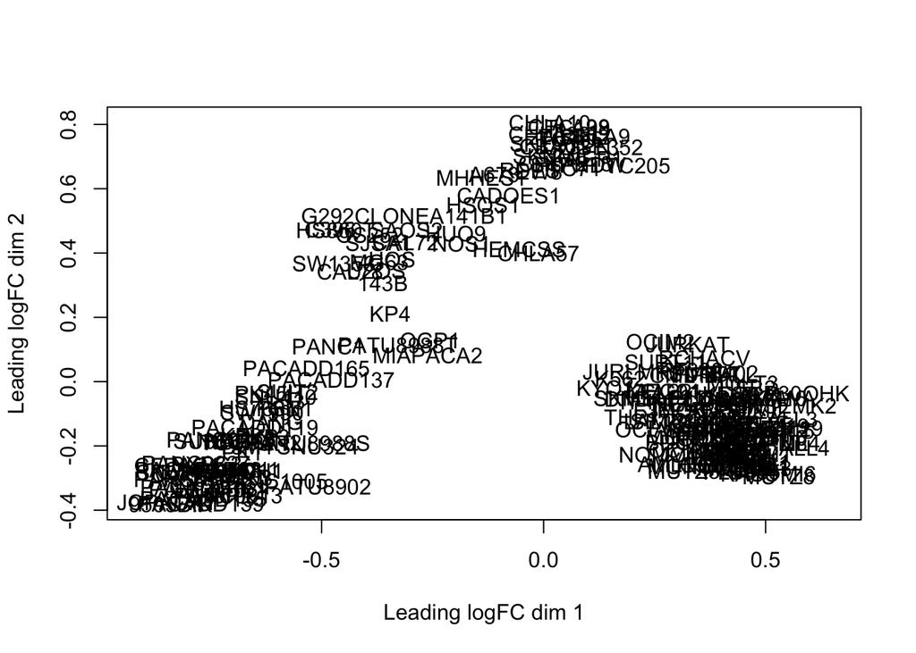

```r
plotMDS(dge)
```

# Differential expression

Set up desing matrix

```r
design = model.matrix(~0+group+primary_disease, data = dge$samples)


colnames(design)
```

```
## [1] "groupNO"                          "groupYES"
## [3] "primary_diseaseLeukemia"          "primary_diseasePancreatic_Cancer"
```

```r
#design
```

Calculate dispersions

```r
dge = estimateDisp(dge, design)
```

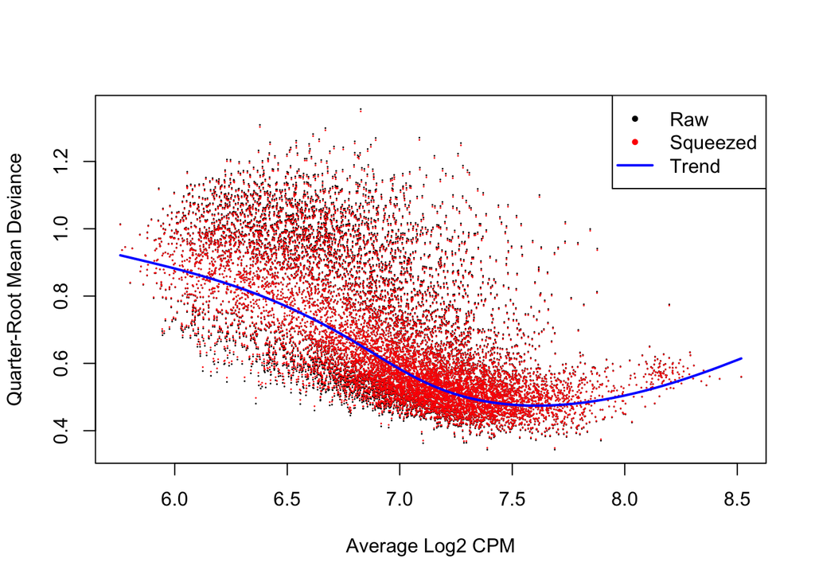

```r
fit <- glmQLFit(dge, design)

plotQLDisp(fit)
```

In order to compare the difference in cell lines with spliceosome mutations vs wt for all different cancers, we need to define some contrasts for the model.

```r
my.contrasts <- makeContrasts(
  YvsN = `groupYES`-`groupNO`,
  levels = design
)
```

Now we are going to use the model contrasts to determine pairwise differential expression using the quasi-likelihood (QL)-F-test

```r
qlf.spliceosome.YvsN <- glmQLFTest(fit, contrast=my.contrasts[,"YvsN"])
topTags(qlf.spliceosome.YvsN)
```

[output not shown]

Adjust p-values (FDR) and merge data into a single table to facilitate the analysis:

```r
TidyQLF = function(qlf, contrast) {
  df_qlf =
    qlf$table %>%
    as_tibble(rownames = "SYMBOL") %>%
    mutate(FDR = p.adjust(PValue, method = "fdr"))

  df_full =
    cbind(qlf$genes,df_qlf) %>%
    mutate(comparison = contrast) %>%
    relocate(SYMBOL, .before = DESCRIPTION) %>%
    relocate(comparison, .before = SYMBOL)

  return(df_full)
}


tbl_YvsN = TidyQLF(qlf.spliceosome.YvsN,"YesvsNo")


head(tbl_YvsN)
```

[output not shown]

## Exploration using PCA/tSNE

Prepare for tSNE/PCA

```r
##PIVOT WIDER
df_wide =
  median_CCLE_expression %>%
  select(DepMap_ID, Gene, TPM, spliceosome_mutated, primary_disease) %>%
  pivot_wider(names_from = Gene, values_from = TPM) %>%
  as.data.frame() %>%
  relocate(DepMap_ID, .after = primary_disease)



expression_pca <- as.matrix(df_wide[,3:11400])
expression <- as.matrix(df_wide[,4:11400])
disease <- df_wide[, 2] #disease
mutated <- df_wide[, 1]

##GET RID OF NA VALUES AND SUBSTITUTE FOR MEAN EXPRESSION PER CELL LINE
for(i in 1:ncol(expression)){
  expression[is.na(expression[,i]), i] <- mean(expression[,i], na.rm = TRUE)
}
```

Run PCA

```r
pca1 = prcomp(expression, center = TRUE, scale = TRUE, na.action=na.omit(expression))
```

```r
plotData = pca1$x[,1:2]
plotData = cbind(DepMap_ID = expression_pca[,1], plotData)
rownames(plotData) = NULL

head(plotData)
```

```
##      DepMap_ID    PC1                 PC2
## [1,] "ACH-001113" "-25.8912390948755" "-11.8772754159592"
## [2,] "ACH-001289" "-32.089833776787"  "-2.23149492296967"
## [3,] "ACH-001339" "15.0538289388188"  "-24.0719270653194"
## [4,] "ACH-001538" "25.7704229940894"  "-16.4639435369173"
## [5,] "ACH-000242" "-5.39230565201994" "1.88725601590978"
## [6,] "ACH-000708" "10.3601145160347"  "9.1981704143161"
```

```r
ID = plotData[,1]

to_join =
  median_CCLE_expression %>%
  select(DepMap_ID, primary_disease, spliceosome_mutated)
plotData %>%
  as_tibble() %>%
  left_join(to_join, by ="DepMap_ID") %>%
  mutate(PC1 = as.double(PC1),
         PC2 = as.double(PC2))  -> plotData_gg
```

Plot

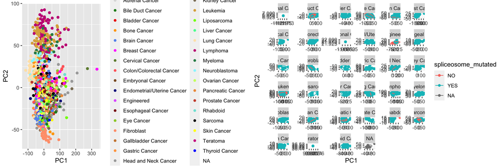

```r
ggplot(plotData_gg, aes(x = PC1,y = PC2, color = spliceosome_mutated)) +
  geom_point() +
  facet_wrap(vars(primary_disease), scales = "free") +
  stat_ellipse() -> gg_expression_mutated

ggsave("/Users/castilln/Desktop/thesis/gg_expression_mutated.png", device = "png", width = 35, height = 20, units = "cm", dpi = "retina")
ggplot(plotData_gg, aes(x = PC1,y = PC2, color = primary_disease)) +
  geom_point() +
  scale_color_manual(values = c("gainsboro", 'forestgreen', 'red2', 'orange',  'cornflowerblue',
                'magenta', 'darkolivegreen4',  'indianred1',  'tan4', 'darkblue',
                'mediumorchid1', 'firebrick4',  'yellowgreen', 'lightsalmon', 'tan3',
                "tan1",  'darkgray','wheat4',  '#DDAD4B',  'chartreuse',
                 'seagreen1', 'moccasin',   'mediumvioletred', 'seagreen', 'cadetblue1',
                "darkolivegreen1" ,"tan2" ,  "tomato3" , "#7CE3D8", "black", "yellow", "violetred", "blue")) -> gg_expression_disease

  ggsave("/Users/castilln/Desktop/thesis/gg_expression_disease.png", device = "png", width = 25, height = 15, units = "cm", dpi = "retina")
grid.arrange(gg_expression_disease, gg_expression_mutated, ncol = 2)
```

Run tSNE

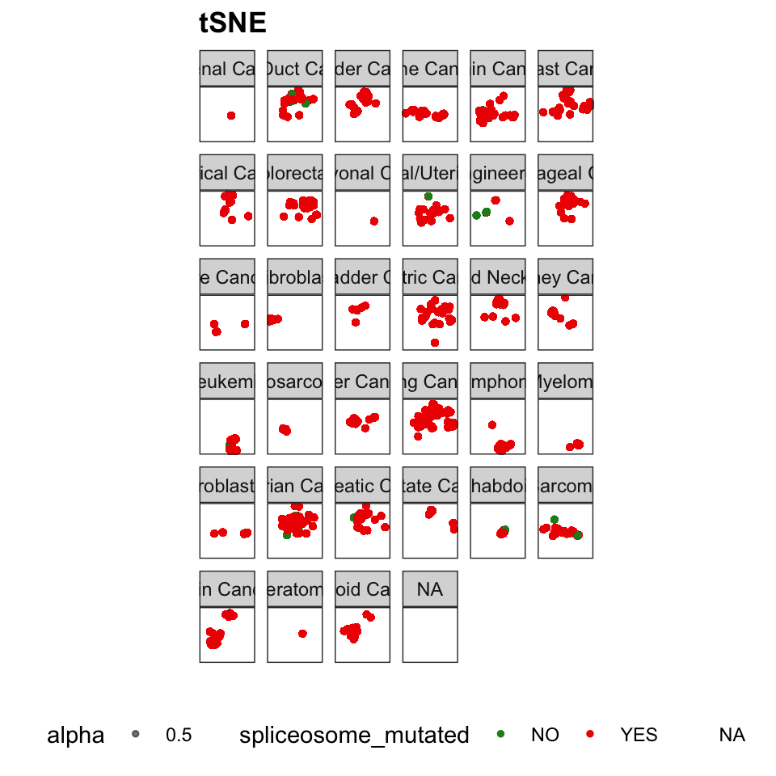

```r
set.seed(6)
tsne_results <- Rtsne(expression, dims = 2, perplexity = 30, theta = 0.5, check_duplicates = FALSE, pca = TRUE)

#plot

plotData =
  tsne_results$Y %>%
  as_tibble() %>%
  mutate(DepMap_ID = ID)
plotData =
  plotData %>%
  left_join(to_join, by ="DepMap_ID") %>%
  mutate(V1 = as.double(V1),
         V2 = as.double(V2))

plotData %>%
  ggplot(aes(x = V1,y = V2, color = spliceosome_mutated)) +
  geom_point(aes(alpha=0.5), size = 1) +
  xlab(element_blank()) +
  ylab(element_blank()) +
  facet_wrap(vars(primary_disease)) +
  theme_bw() +
  ggtitle("tSNE") +
  theme(legend.position = "bottom",
        aspect.ratio = 1,
        axis.text.x = element_blank(),
        axis.text.y = element_blank(),
        panel.grid.major = element_blank(),
        panel.grid.minor = element_blank(),
        axis.ticks = element_blank(),
        plot.title = element_text(face = "bold")) +
  scale_color_manual(values = c('forestgreen', 'red2')) ->tsne_expression

ggsave("/Users/castilln/Desktop/thesis/tsne_expression.png", device = "png", width = 30, height = 25, units = "cm", dpi = "retina")
print(tsne_expression)
```